# IS 590DV - Data Visualization Final Project (Part III)

## Authors: Gaurav, Mubeen, Vinu, Srikanth

### This project aims at analyzing the mass shootings incidents occurred in the United States between 1982-2019.

We have analyzed the different aspects of data including location, number of incidents/year, number of victims, latitude, longitude to come up with visualizations and gain meaningful insights from the data.

## Introduction:

> This dataset provides information on mass shooting occurences since the year 1982. The dataset has 115 rows and 24 columns of information. The data is diverse and provides as host of information ranging from the location to fatalities and total victims to information pertaining to the shooter like his age, prior mental health issues, race ,gender, etc.

> We chose this dataset as mass shootings are a relevant issue today in the USA, with many lives being lost due to acts of gun violence by obnoxious people. Our aim with the project was to see patterns in the data like the race of the shooter, increase in the incident rate over the years and why this is an issue that needs to be seriously addressed.

> Below, we are going to see how the information from the dataset can be used to create meaningful data visualizations that convey important facts and figures from the dataset to the viewers, who in this case do not have good insight into the data themselves.

## Libraries Used for visualization

- seaborn
- ipywidgets
- folium
- matplotlib
- plotly

## Loading Dataset

```
Index(['case', 'location', 'date', 'summary', 'fatalities', 'injured',
       'total_victims', 'location.1', 'age_of_shooter',
       'prior_signs_mental_health_issues', 'mental_health_details',
       'weapons_obtained_legally', 'where_obtained', 'weapon_type',
       'weapon_details', 'race', 'gender', 'sources', 'mental_health_sources',
       'sources_additional_age', 'latitude', 'longitude', 'type', 'year'],
      dtype='object')

Shape of the data:  (115, 24)
```

|  | case | location | date | summary | fatalities | injured | total_victims | location.1 | age_of_shooter | prior_signs_mental_health_issues | ... | weapon_details | race | gender | sources | mental_health_sources | sources_additional_age | latitude | longitude | type | year |
| --- | --- | --- | --- | --- | --- | --- | --- | --- | --- | --- | --- | --- | --- | --- | --- | --- | --- | --- | --- | --- | --- |
| 0 | Odessa-Midland shooting spree | Odessa, Texas | 2019-08-31 | Seth A. Ator, 36, fired at police officers who... | 7 | 25 | 32 | Other | 36 | yes | ... | - | White | M | https://www.washingtonpost.com/politics/5-kill... | https://www.nytimes.com/2019/09/02/us/texas-gu... | - | 31.925974 | -102.279600 | Spree | 2019 |
| 1 | Dayton entertainment district shooting | Dayton, Ohio | 2019-08-04 | Connor Betts, 24, died during the attack, foll... | 9 | 27 | 36 | Other | 24 | - | ... | AR-15-style rifle, with a 100-round capacity a... | White | M | https://www.nytimes.com/2019/08/04/us/dayton-o... | - | - | 39.757312 | -84.184947 | Mass | 2019 |
| 2 | El Paso Walmart mass shooting | El Paso, Texas | 2019-08-03 | Patrick Crusius, 21, who was apprehended by po... | 22 | 26 | 48 | Workplace | 21 | - | ... | AK-47-style rifle, per authorities | White | M | https://www.washingtonpost.com/nation/2019/08/... | - | - | 31.771068 | -106.375655 | Mass | 2019 |
| 3 | Gilroy garlic festival shooting | Gilroy, California | 2019-07-28 | Santino William LeGan, 19, fired indiscriminat... | 3 | 12 | 15 | Other | 19 | TBD | ... | AK-47-style rifle, per authorities | - | M | https://www.cbsnews.com/live-news/garlic-festi... | - | - | 36.997191 | -121.584819 | Mass | 2019 |
| 4 | Virginia Beach municipal building shooting | Virginia Beach, Virginia | 2019-05-31 | DeWayne Craddock, 40, a municipal city worker ... | 12 | 4 | 16 | Workplace | 40 | TBD | ... | .45-caliber handguns; noise suppressor (silenc... | Black | M | https://www.washingtonpost.com/local/public-sa... | - | - | 36.754420 | -76.060378 | Mass | 2019 |

5 rows × 24 columns

## Dataset Description and Definitions

It does not include shootings resulting from more primitive incidents such as armed robbery or gang violence.

It also includes interesting information about the registered case, location, weapin used, vicitms, number of persons injured and detailed about the shooter age, race, gender and whether the shooter had prior sign of mental health issues.

The columns are as follows:

- Case:- It contains the name of the shooting registered in the dataset.
- location:- It contains the name of different state location within the United states where shooting happened.
- date:- Contains the date and year of the shooting.
- summary:- It contains the detail information about the shooting, what are the reasons behind the shooting and how many people were killed.
- fatalities:- It contains the information for an occurrence of death in mass shooting.
- injured:- Contains number of people injured in shooting.
- total_victims:- Contains the information about the total number of victims present while shooting.
- location_2:- It also contains the location of shooting happened in different location like school and workplace.
- age_of_shooter:- Information about the age of shooter.
- prior_signs_mental_health_issues:- It contains information about any mental sign of the shooter.
- mental_health_details:- Contains details of mental health detail of shooter, like whether the mental condition of shooter was good or bad before he had done the crime.
- weapons_obtained_legally:- Information of the weapons obtained by shooter is legall or inlegall.
- where_obtained:- Information from where shooter purchased or obtained the weapon.
- weapon_type:- Detailed information about the typer of weapon used, like whether its a handgun or shotgun.
- race:- Information of the shooter belongs to which racial division or ethic group
- gender:- Contains information whether shooter is male or female.
- sources:- It contains information from where we got the shooting report, whether from news channel or blogs.
- type:- It contains the information about the type of shooting. Whether its Sperr which involve two or more victim died and Mass which involve mutliple victims or groups of peoples killed in gun shooting.
- year:- Information in which year shooting happend.

```
<class 'pandas.core.frame.DataFrame'>
RangeIndex: 115 entries, 0 to 114
Data columns (total 24 columns):
case                                115 non-null object
location                            115 non-null object
date                                115 non-null datetime64[ns]
summary                             115 non-null object
fatalities                          115 non-null int64
injured                             115 non-null int64
total_victims                       115 non-null int64
location.1                          115 non-null object
age_of_shooter                      115 non-null int64
prior_signs_mental_health_issues    115 non-null object
mental_health_details               115 non-null object
weapons_obtained_legally            115 non-null object
where_obtained                      115 non-null object
weapon_type                         115 non-null object
weapon_details                      115 non-null object
race                                115 non-null object
gender                              115 non-null object
sources                             115 non-null object
mental_health_sources               115 non-null object
sources_additional_age              115 non-null object
latitude                            115 non-null float64
longitude                           115 non-null float64
type                                115 non-null object
year                                115 non-null int64
dtypes: datetime64[ns](1), float64(2), int64(5), object(16)
memory usage: 21.7+ KB
```

|  | fatalities | injured | total_victims | age_of_shooter | latitude | longitude | year |
| --- | --- | --- | --- | --- | --- | --- | --- |
| count | 115.000000 | 115.000000 | 115.000000 | 115.000000 | 115.000000 | 115.000000 | 115.000000 |
| mean | 8.182609 | 12.443478 | 20.626087 | 34.200000 | 37.328014 | -96.860392 | 2007.860870 |
| std | 8.018162 | 51.316047 | 56.950958 | 11.975999 | 5.768452 | 18.069974 | 10.396429 |
| min | 3.000000 | 0.000000 | 3.000000 | 11.000000 | 21.320063 | -157.876462 | 1982.000000 |
| 25% | 5.000000 | 1.000000 | 7.000000 | 24.500000 | 33.650517 | -117.463124 | 1999.000000 |
| 50% | 6.000000 | 4.000000 | 11.000000 | 34.000000 | 38.254238 | -91.081403 | 2012.000000 |
| 75% | 9.000000 | 11.500000 | 18.500000 | 42.500000 | 41.508325 | -81.335431 | 2017.000000 |
| max | 58.000000 | 546.000000 | 604.000000 | 66.000000 | 48.461367 | -71.075913 | 2019.000000 |

# Using Openrefine to clean the dataset

## The changes done are:

### Columns: Case, Location, Summary, Location2, Mental health sources, Race, Gender, Sources, Mental health sources, Sources additional age, Type

Changes: Trim leading and trailing white spaces, Collapse consecutive whitespace, column is converted to text type, Convert to title case, Created a cluster and merged similar values

### Columns: Fatalities, Injured, Total_victims, Age of shooter, Latitude, Longitude, Year

Changes: Column is converted to number type, created numeric facets to check the range (to make sure there were no invalid values like negative numbers)

### Columns: Prior signs of mental health, Weapons obtained legally, Where obtained, Weapon type, Weapon details

Changes: Created text facet and changed all the different values to either 'Yes', 'No', 'Unknown' and specific values, changed column to Titlecase

```
Shape of the data:  (115, 24)
```

|  | case | location | date | summary | fatalities | injured | total_victims | location2 | age_of_shooter | prior_signs_mental_health_issues | ... | weapon_details | race | gender | sources | mental_health_sources | sources_additional_age | latitude | longitude | type | year |
| --- | --- | --- | --- | --- | --- | --- | --- | --- | --- | --- | --- | --- | --- | --- | --- | --- | --- | --- | --- | --- | --- |
| 0 | Odessa-midland Shooting Spree | Odessa, Texas | Sat Aug 31 00:00:00 CDT 2019 | Seth A. Ator, 36, fired at police officers who... | 7 | 25 | 32 | Other | 36 | Yes | ... | Unknown | White | Male | https://www.washingtonpost.com/politics/5-kill... | https://www.nytimes.com/2019/09/02/us/texas-gu... | - | 31.925974 | -102.279600 | Spree | 2019 |
| 1 | Dayton Entertainment District Shooting | Dayton, Ohio | Sun Aug 04 00:00:00 CDT 2019 | Connor Betts, 24, died during the attack, foll... | 9 | 27 | 36 | Other | 24 | Unknown | ... | AR-15-style rifle, with a 100-round capacity a... | White | Male | https://www.nytimes.com/2019/08/04/us/dayton-o... | - | - | 39.757312 | -84.184947 | Mass | 2019 |
| 2 | El Paso Walmart Mass Shooting | El Paso, Texas | Sat Aug 03 00:00:00 CDT 2019 | Patrick Crusius, 21, who was apprehended by po... | 22 | 26 | 48 | Workplace | 21 | Unknown | ... | AK-47-style rifle, per authorities | White | Male | https://www.washingtonpost.com/nation/2019/08/... | - | - | 31.771068 | -106.375655 | Mass | 2019 |
| 3 | Gilroy Garlic Festival Shooting | Gilroy, California | Sun Jul 28 00:00:00 CDT 2019 | Santino William LeGan, 19, fired indiscriminat... | 3 | 12 | 15 | Other | 19 | Unknown | ... | AK-47-style rifle, per authorities | Unknown | Male | https://www.cbsnews.com/live-news/garlic-festi... | - | - | 36.997191 | -121.584819 | Mass | 2019 |
| 4 | Virginia Beach Municipal Building Shooting | Virginia Beach, Virginia | Fri May 31 00:00:00 CDT 2019 | DeWayne Craddock, 40, a municipal city worker ... | 12 | 4 | 16 | Workplace | 40 | Unknown | ... | .45-caliber handguns; noise suppressor (silenc... | Black | Male | https://www.washingtonpost.com/local/public-sa... | - | - | 36.754420 | -76.060378 | Mass | 2019 |

5 rows × 24 columns

## Visualization 1: Number of mass shootings grouped by gender

We wanted to check the gender breakdown of the shooters for all the years between 1982 - 2019. The first visualization is an interactive bar plot showing the gender breakdown of the shooters for all shootings. We used Pyplot package to make use of the interactive features.

[interactive chart not shown]

### Explanation and Inferences:

> The dataset was first grouped by year and gender for plotting. We then created a list of values for all the 3 categories mentioned in the gender and supplied this list as a parameter while plotting the bar graph. We can hover over the bar and it will show the year and the exact count.

> We see that around 97% of the shootings (Men total = 111, Female total = 3, Others total = 1) have been caused by Men. This knowledge combined with the mental health data can be used to predict the likelihood of a person getting involved in a shooting.

## Visualization 2: Total victims grouped by race

For our second visualization, we wanted to see the breakdown of the shooters by race for all years between 1982 - 2019. This is an interactive plot too and we used Pyplot package to create it.

[interactive chart not shown]

### Explanation and Inferences:

> We first grouped the data by race and type and sorted the dataframe based on total victim count. Just to get a clear idea, we wanted to break it further down by the type of event (Either mass or spree). We can hover over the bar and it will show the count of victims, race and the type of shooting.

> We see that the majority of the incidents have been committed by Whites, but it is also because White people make up the majority of the US population. We further see Black, Asian and Other races have a few incidents too least being Native American. Also, we see that the number of mass shootings are considerably more than the number of spree shootings.

## Visualization 3: Total Victims of Mass Shooting Per Year

For the third visualization, we wanted to see how massive have the shootings been in terms of number of victims in each passing year.

```
year
1982     11
1984     48
1986     21
1987     20
1988     11
1989     56
1990     14
1991     61
1992     19
1993     57
1994     28
1995      6
1996      7
1997     14
```

[output cut: 22 more lines]

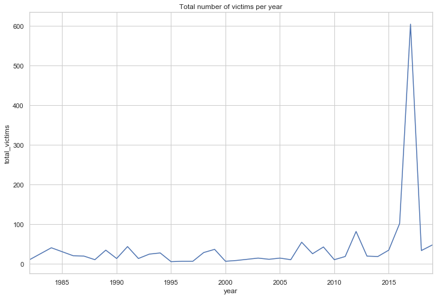

## Visualization 4: Total Number of incidents per year

The main aim to study this visualization is to understand whether the number of shooting incidents have increased or decreased from 1982 to 2019.

```
year
1982     1
1984     2
1986     1
1987     1
1988     1
1989     2
1990     1
1991     3
1992     2
1993     4
1994     1
1995     1
1996     1
1997     2
```

[output cut: 22 more lines]

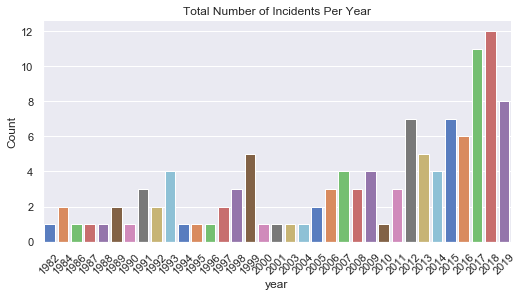

### Explanation and Inferences:

> For this visualization Seaborn was used. Seaborn is an easy to use package which provides colurful visualizations and matplotlib can be used style seaborn visualizations. This is a factorplot which shows as a column chart and we can see that the incident rate has increased over the years. In 1982 only 1 incident of mass shooting had occurred and in 2018 12 incidents to go with 8 incidents in 2019.

> The x axis here is the year column from the dataset and y axis is the count of type of incidents from the dataset. To obtain this factorplot type was grouped by the year and count was taken using the size function shooting[['year', 'type']].groupby(['year']).size(). This was then used to create the graph. For some styling in the factorplot the x axis labels are rotated by 45 degreees using xticklabels

## Visualization 5: Total Injured Per Year

For our fifth visualization, we intended to understand the average number of people that were injured in these mass shooting incident each year.

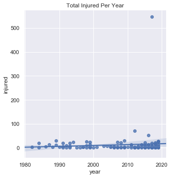

## Visualization 6: Plotting geospatial data on map with details on the incidents with varying sizes of circle depicting the severity of incident

This visualization was devised to understand which states/cities in the US are observing higher shooting rates and the severity of incidents.

[interactive chart not shown]

### Explanation and Inferences:

> This plot depicts the various locations across US where mass shooting incidents have occurred from 1982-2019. The radius of each circle represent the severity of the incident factored by a scalar value. The severity of incident is decided by the total number of victims of that incident. On click of each of the circle, we see details of the incident such as the location, case reported, total victims and the year the case occurred.

## Visualization 7: Exploring widgets for scatterplot

This visualization aimed at providing a UI widget with flexibility for the user to pick and observe the trend of various mass shooting observatory data against other parameters.

## Conclusion

> This project was a great learning experience on how to create visualizations that cater to the general public with minimal technical knowledge. These users could have next to no information on the data and every visualization must be highly narrative and interactive so as to convey the idea unmistakably to the user, while representing the data in a meaningful manner, with respect to the purpose behind the visualization.

> We also learned how to work as a group to identify a good dataset, identify the ways the data could be manipulated in order to create these visualizations and how to connect these visualizations to real-world issues and analysis. For instance, through this dataset, we learned about the top places with shooting incidents and the timeline and trends of shootings in the US.